# Raw Loan Analysis

### Load libraries

```r
library(Hmisc)
```

## Processing

Download the data, read the data in and save the raw data as an RDA file

```r
getwd()
```

```
## [1] "C:/dev/coursera/cour-dataanalysis/a1/code/rawcode"
```

```r
download.file("https://spark-public.s3.amazonaws.com/dataanalysis/loansData.csv",
    destfile = "../../data/loansData.csv", method = "curl")
dateDownloaded <- date()
dateDownloaded
```

```
## [1] "Thu Feb 14 17:02:04 2013"
```

```r
loansRaw <- read.csv("../../data/loansData.csv")
save(loansRaw, dateDownloaded, file = "../../data/loansRaw.rda")
```

### Look at the data set

```r
head(loansRaw)
```

```
##       Amount.Requested Amount.Funded.By.Investors Interest.Rate
## 81174            20000                      20000         8.90%
## 99592            19200                      19200        12.12%
## 80059            35000                      35000        21.98%
## 15825            10000                       9975         9.99%
## 33182            12000                      12000        11.71%
## 62403             6000                       6000        15.31%
##       Loan.Length       Loan.Purpose Debt.To.Income.Ratio State
## 81174   36 months debt_consolidation               14.90%    SC
## 99592   36 months debt_consolidation               28.36%    TX
## 80059   60 months debt_consolidation               23.81%    CA
## 15825   36 months debt_consolidation               14.30%    KS
## 33182   36 months        credit_card               18.78%    NJ
## 62403   36 months              other               20.05%    CT
##       Home.Ownership Monthly.Income FICO.Range Open.CREDIT.Lines
```

[output cut: 20 more lines]

```r
summary(loansRaw)
```

```
##  Amount.Requested Amount.Funded.By.Investors Interest.Rate
##  Min.   : 1000    Min.   :    0              12.12% : 122
##  1st Qu.: 6000    1st Qu.: 6000              7.90%  : 119
##  Median :10000    Median :10000              13.11% : 115
##  Mean   :12406    Mean   :12002              15.31% :  76
##  3rd Qu.:17000    3rd Qu.:16000              14.09% :  72
##  Max.   :35000    Max.   :35000              14.33% :  69
##                                              (Other):1927
##     Loan.Length               Loan.Purpose  Debt.To.Income.Ratio
##  36 months:1952   debt_consolidation:1307   0%     :   8
##  60 months: 548   credit_card       : 444   12.54% :   6
##                   other             : 201   12.20% :   5
##                   home_improvement  : 152   12.85% :   5
##                   major_purchase    : 101   14.22% :   5
##                   small_business    :  87   14.66% :   5
##                   (Other)           : 208   (Other):2466
##      State       Home.Ownership Monthly.Income     FICO.Range
##  CA     : 433   MORTGAGE:1148   Min.   :   588   670-674: 171
##  NY     : 255   NONE    :   1   1st Qu.:  3500   675-679: 166
##  TX     : 174   OTHER   :   5   Median :  5000   680-684: 157
##  FL     : 169   OWN     : 200   Mean   :  5689   695-699: 153
##  IL     : 101   RENT    :1146   3rd Qu.:  6800   665-669: 145
##  GA     :  98                   Max.   :102750   690-694: 140
##  (Other):1270                   NA's   :1        (Other):1568
##  Open.CREDIT.Lines Revolving.CREDIT.Balance Inquiries.in.the.Last.6.Months
##  Min.   : 2.0      Min.   :     0           Min.   :0.000
##  1st Qu.: 7.0      1st Qu.:  5586           1st Qu.:0.000
##  Median : 9.0      Median : 10962           Median :0.000
##  Mean   :10.1      Mean   : 15245           Mean   :0.906
##  3rd Qu.:13.0      3rd Qu.: 18889           3rd Qu.:1.000
##  Max.   :38.0      Max.   :270800           Max.   :9.000
##  NA's   :2         NA's   :2                NA's   :2
##  Employment.Length
##  10+ years:653
##  < 1 year :250
##  2 years  :244
##  3 years  :235
##  5 years  :202
##  4 years  :192
##  (Other)  :724
```

```r
sapply(loansRaw[1, ], class)
```

```
##               Amount.Requested     Amount.Funded.By.Investors
##                      "integer"                      "numeric"
##                  Interest.Rate                    Loan.Length
##                       "factor"                       "factor"
##                   Loan.Purpose           Debt.To.Income.Ratio
##                       "factor"                       "factor"
##                          State                 Home.Ownership
##                       "factor"                       "factor"
##                 Monthly.Income                     FICO.Range
##                      "numeric"                       "factor"
##              Open.CREDIT.Lines       Revolving.CREDIT.Balance
##                      "integer"                      "integer"
## Inquiries.in.the.Last.6.Months              Employment.Length
##                      "integer"                       "factor"
```

### Find out about missing values

```r
sum(is.na(loansRaw))
```

```
## [1] 7
```

### Find minimum and maximum interest rates

```r
rates <- as.numeric(sub("%", "", loansRaw$Interest.Rate))
min(rates)
```

```
## [1] 5.42
```

```r
max(rates)
```

```
## [1] 24.89
```

### Find minimum and maximum debts to income ratio

```r
ratio <- as.numeric(sub("%", "", loansRaw$Debt.To.Income.Ratio))
min(ratio)
```

```
## [1] 0
```

```r
max(ratio)
```

```
## [1] 34.91
```

## Exploratory analysis

### Make some univariate plots/summaries

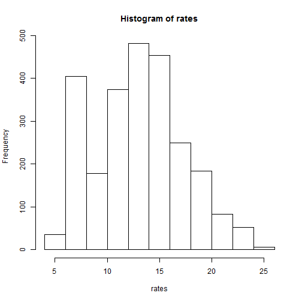

```r
hist(rates)
```

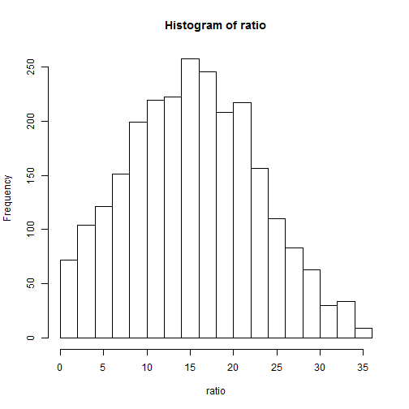

```r
hist(ratio)
```

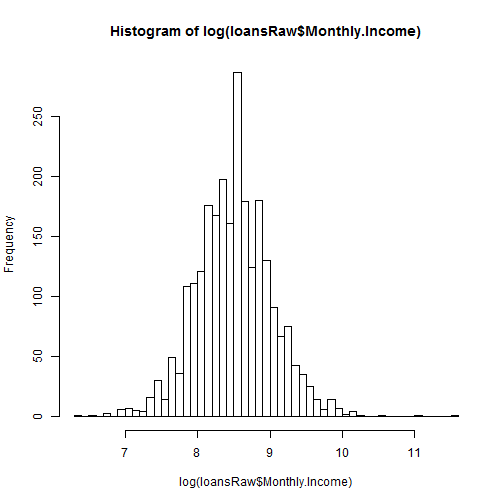

```r
hist(log(loansRaw$Monthly.Income), breaks = 50)
```

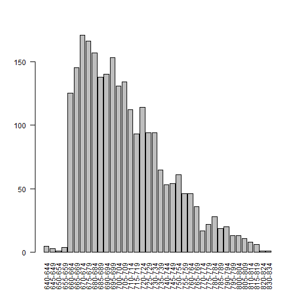

```r
plot(loansRaw$FICO.Range, las = 2)
```

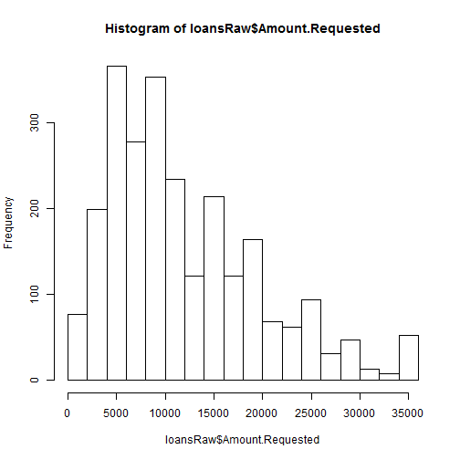

```r
hist(loansRaw$Amount.Requested)
```

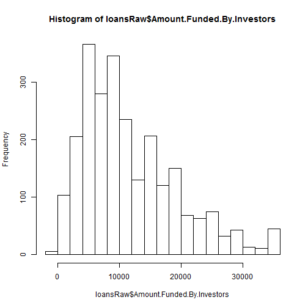

```r
hist(loansRaw$Amount.Funded.By.Investors)
```

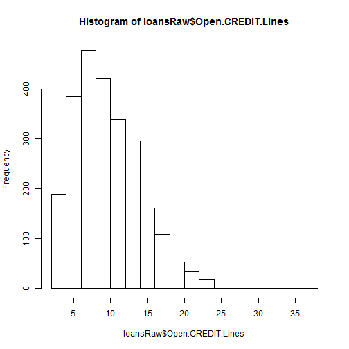

```r
hist(loansRaw$Open.CREDIT.Lines)
```

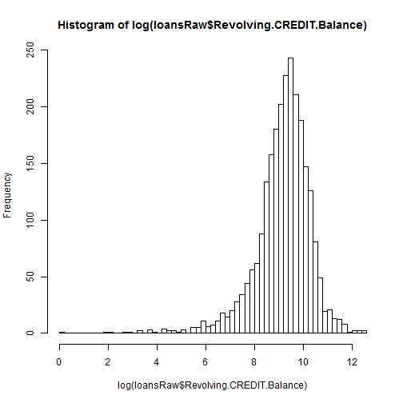

```r
hist(log(loansRaw$Revolving.CREDIT.Balance), breaks = 50)
```

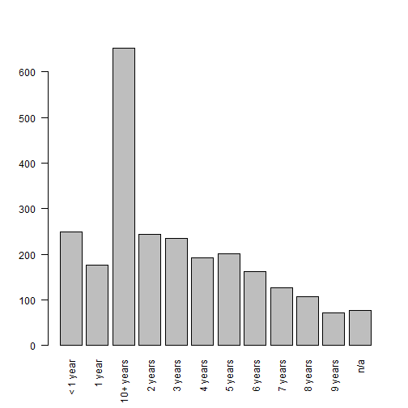

```r
plot(loansRaw$Employment.Length, las = 2)
```

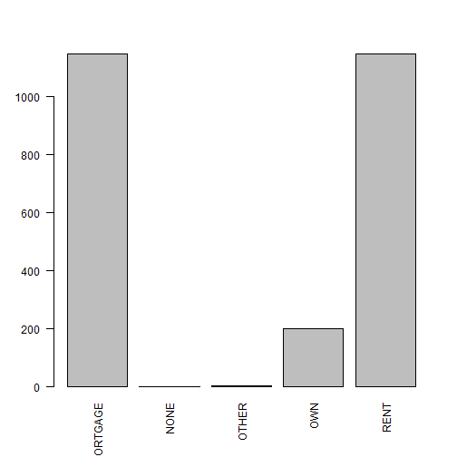

```r
plot(loansRaw$Home.Ownership, las = 2)
```

### Make some univariate tables

```r
table(loansRaw$FICO.Range)
```

```
##
## 640-644 645-649 650-654 655-659 660-664 665-669 670-674 675-679 680-684
##       5       3       1       4     125     145     171     166     157
## 685-689 690-694 695-699 700-704 705-709 710-714 715-719 720-724 725-729
##     138     140     153     131     134     112      93     114      94
## 730-734 735-739 740-744 745-749 750-754 755-759 760-764 765-769 770-774
##      94      65      53      54      61      46      46      36      17
## 775-779 780-784 785-789 790-794 795-799 800-804 805-809 810-814 815-819
##      22      28      19      20      13      13      11       8       6
## 820-824 830-834
##       1       1
```

```r
table(loansRaw$Interest.Rate)
```

```
##
## 10.00% 10.08% 10.16% 10.20% 10.25% 10.28% 10.36% 10.37% 10.38% 10.46%
##      8      2     48      1      8      1      8      8     12      1
## 10.59% 10.62% 10.65% 10.74% 10.75% 10.83% 10.91% 10.95% 10.99% 11.03%
##     13      5     14     24     11      2      1      1     20      4
## 11.09% 11.11% 11.12% 11.14% 11.26% 11.36% 11.48% 11.49% 11.54% 11.58%
##      1      6      8     58      2      4      6     21      1      2
## 11.59% 11.66% 11.71% 11.78% 11.83% 11.86% 11.89% 11.97% 11.99% 12.12%
##      1      1     36      2      8      7      9      3     14    122
## 12.18% 12.21% 12.23% 12.29% 12.41% 12.42% 12.49% 12.53% 12.61% 12.68%
##      4      5      3      2      1     17      1     10      5      7
## 12.69% 12.73% 12.84% 12.86% 12.87% 12.92% 12.98% 12.99% 13.06% 13.11%
##     21      2      5      1      4      3      4      6      8    115
## 13.12% 13.16% 13.17% 13.22% 13.23% 13.24% 13.30% 13.35% 13.43% 13.47%
##      1      4      1      2      5      2      2      2      4      3
## 13.48% 13.49% 13.55% 13.57% 13.61% 13.67% 13.72% 13.75% 13.79% 13.80%
##      4     25      1      1      2     23      2      2      2      1
## 13.85% 13.87% 13.92% 13.93% 13.98% 13.99% 14.07% 14.09% 14.11% 14.12%
##      4      2      2      1      8     29      2     72      7      1
## 14.17% 14.18% 14.22% 14.26% 14.27% 14.33% 14.35% 14.42% 14.46% 14.50%
##      3      1      4      2     18     69      4      2      3      1
## 14.59% 14.61% 14.65% 14.70% 14.72% 14.74% 14.79% 14.82% 14.83% 14.84%
##      5      4     29      2      3      2      2      2      3      2
## 14.91% 14.96% 15.01% 15.05% 15.13% 15.20% 15.21% 15.23% 15.27% 15.28%
##      5      6      1      4      2      1      5      7     10      2
## 15.31% 15.33% 15.37% 15.45% 15.57% 15.58% 15.62% 15.65% 15.68% 15.70%
##     76      3      1      1      1      5      3      3      1      1
## 15.80% 15.81% 15.95% 15.96% 15.99% 16.00% 16.02% 16.07% 16.29% 16.32%
##     39     10      5     10      7      2      2      2     51      8
## 16.35% 16.40% 16.45% 16.49% 16.63% 16.69% 16.70% 16.71% 16.77% 16.82%
##      1      2      1      8      1      1      1      1     11      5
## 16.83% 16.89% 17.04% 17.14% 17.15% 17.19% 17.27% 17.43% 17.44% 17.49%
##      1      9      1      4      1      1     56      1      1     10
## 17.51% 17.54% 17.56% 17.58% 17.77% 17.80% 17.88% 17.90% 17.93% 17.99%
##      3      1      3      6     38      1      1      1      3     12
## 18.17% 18.25% 18.29% 18.30% 18.39% 18.49% 18.55% 18.62% 18.64% 18.67%
##      1     19      1      1      3     33      7      1      8      2
## 18.75% 18.79% 19.03% 19.04% 19.05% 19.13% 19.22% 19.41% 19.42% 19.47%
##     17      3      7      1     26      1      9      1      3      1
## 19.69% 19.72% 19.74% 19.91% 19.99% 20.25% 20.30% 20.49% 20.50% 20.52%
##      5     19      2      5      7      2      3     18      6      1
## 20.53% 20.77% 20.89% 20.99% 21.00% 21.14% 21.27% 21.28% 21.48% 21.49%
##      1      2      1      1     12      1      1      1      4     12
## 21.67% 21.74% 21.97% 21.98% 22.11% 22.45% 22.47% 22.78% 22.95% 23.28%
##      2      2      3     10      2      3     15      5      8      7
## 23.33% 23.63% 23.76% 23.83% 23.91% 24.20% 24.33% 24.70% 24.89%  5.42%
##      1      1      7      2      1      1      1      2      2     11
##  5.79%  5.99%  6.00%  6.03%  6.17%  6.54%  6.62%  6.76%  6.91%  6.92%
##     14     10      1     57      5      6     49      4      9      5
##  6.99%  7.14%  7.29%  7.40%  7.43%  7.49%  7.51%  7.62%  7.66%  7.68%
##      9      7     10      3      1     23     21     34      8      3
##  7.74%  7.75%  7.88%  7.90%  7.91%  8.00%  8.07%  8.32%  8.49%  8.59%
##      5      2     17    119      3      4      1      2     10      7
##  8.63%  8.88%  8.90%  8.94%  9.07%  9.20%  9.25%  9.32%  9.33%  9.62%
##      2      3     64      7      2      1      3      4      1      3
##  9.63%  9.76%  9.88%  9.91%  9.99%
##     11     21      4     13     11
```

```r
table(loansRaw$Loan.Length)
```

```
##
## 36 months 60 months
##      1952       548
```

```r
table(loansRaw$State)
```

```
##
##  AK  AL  AR  AZ  CA  CO  CT  DC  DE  FL  GA  HI  IA  IL  IN  KS  KY  LA
##  11  38  13  46 433  61  50  11   8 169  98  12   1 101   3  21  23  22
##  MA  MD  MI  MN  MO  MS  MT  NC  NH  NJ  NM  NV  NY  OH  OK  OR  PA  RI
##  73  68  45  38  33   1   7  64  15  94  13  32 255  71  21  30  96  15
##  SC  SD  TX  UT  VA  VT  WA  WI  WV  WY
##  28   4 174  16  78   5  58  26  15   4
```

```r
table(loansRaw$Loan.Purpose)
```

```
##
##                car        credit_card debt_consolidation
##                 50                444               1307
##        educational   home_improvement              house
##                 15                152                 20
##     major_purchase            medical             moving
##                101                 30                 29
##              other   renewable_energy     small_business
##                201                  4                 87
##           vacation            wedding
##                 21                 39
```

```r
table(loansRaw$Home.Ownership)
```

```
##
## MORTGAGE     NONE    OTHER      OWN     RENT
##     1148        1        5      200     1146
```

```r
table(loansRaw$Inquiries.in.the.Last.6.Months)
```

```
##
##    0    1    2    3    4    5    6    7    8    9
## 1250  657  336  169   50   14    8    7    2    5
```

```r
table(loansRaw$Employment.Length)
```

```
##
##  < 1 year    1 year 10+ years   2 years   3 years   4 years   5 years
##       250       177       653       244       235       192       202
##   6 years   7 years   8 years   9 years       n/a
##       163       127       108        72        77
```

### Plot rate by FICO

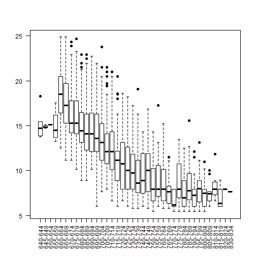

```r
plot(loansRaw$FICO.Range, rates, pch = 19, las = 2)
```

Have correlation between FICO and Rate. Than bigger FICO than less Rate. Since FICO is aggregation of other factors, cofounders should be found

### Plot Rate by FICO with color groups for loan lengths

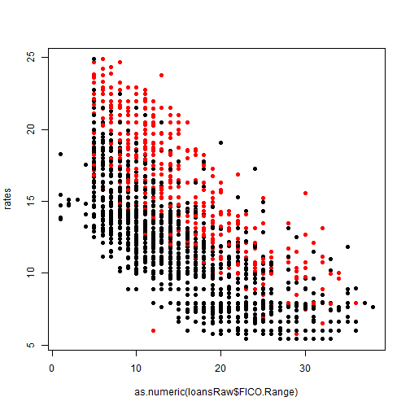

```r
plot(as.numeric(loansRaw$FICO.Range), rates, pch = 19, col = loansRaw$Loan.Length)
```

Rates smaller than loan length smaller.

### Plot Rate by Ratio

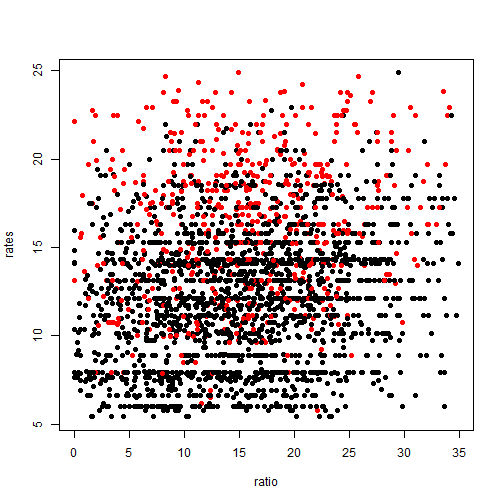

```r
plot(ratio, rates, pch = 19, col = loansRaw$Loan.Length)
```

No obvious correlation

### Plot rate by income

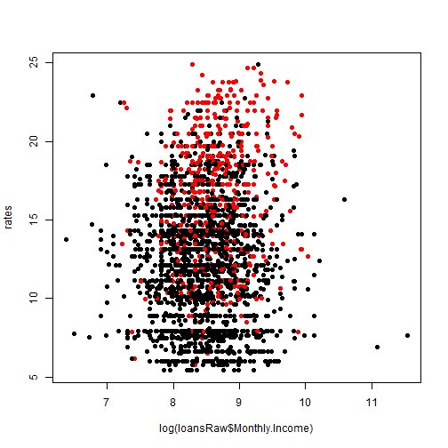

```r
plot(log(loansRaw$Monthly.Income), rates, pch = 19, col = loansRaw$Loan.Length)
```

Again no obvious correlation here

### Plot rate by employment length

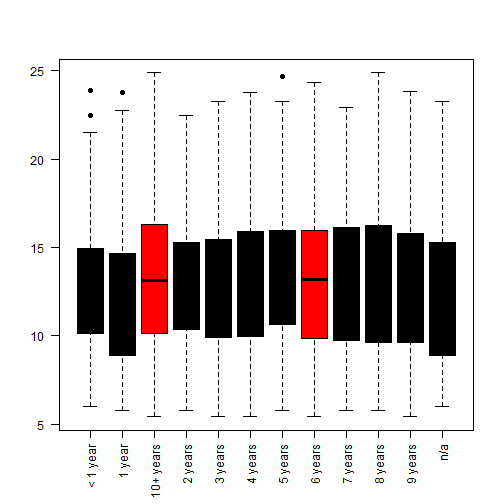

```r
plot(loansRaw$Employment.Length, rates, pch = 19, las = 2, col = loansRaw$Loan.Length)
```

No correlation here

### Plot rate by credit lines

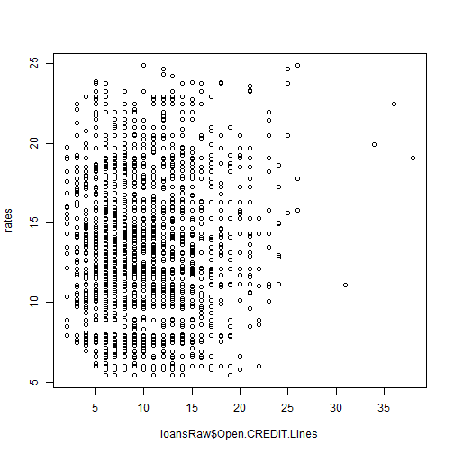

```r
plot(loansRaw$Open.CREDIT.Lines, rates)
```

### Plot rate by purpose

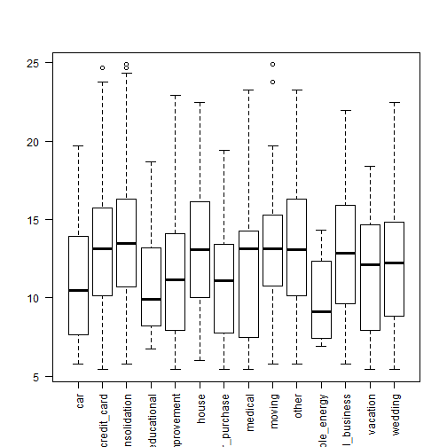

```r
plot(loansRaw$Loan.Purpose, rates, las = 2)
```

In general car, educational and energy has lower rate, maby because they are short term and then loan length is cofounder here

### Plot rate by purpose (long teram term)

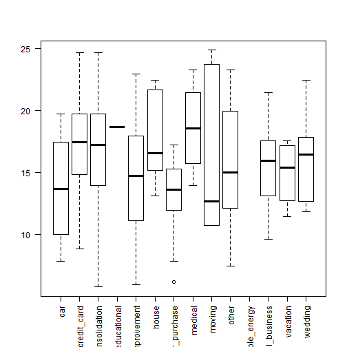

```r
plot(loansRaw$Loan.Purpose[as.numeric(loansRaw$Loan.Length) == 2], rates[as.numeric(loansRaw$Loan.Length) ==
    2], las = 2)  #, cex=as.numeric(loansRaw$Loan.Length), col=as.numeric(loansRaw$Open.CREDIT.Lines))
```

### Plot rate by Inquiries.in.the.Last.6.Months

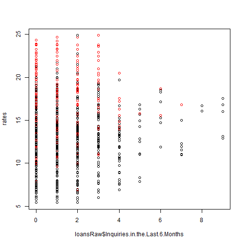

```r
plot(loansRaw$Inquiries.in.the.Last.6.Months, rates, col = loansRaw$Loan.Length)
```

Now lets try to indentify whats else could affect rate.

## Modeling

### Fit a rates by FICO.Range

```r
lm1 <- lm(rates ~ loansRaw$FICO.Range)
summary(lm1)
```

```
##
## Call:
## lm(formula = rates ~ loansRaw$FICO.Range)
##
## Residuals:
##    Min     1Q Median     3Q    Max
## -8.147 -2.041 -0.492  1.666 10.403
##
## Coefficients:
##                            Estimate Std. Error t value Pr(>|t|)
## (Intercept)                 15.2120     1.2697   11.98  < 2e-16 ***
## loansRaw$FICO.Range645-649  -0.3287     2.0734   -0.16  0.87406
## loansRaw$FICO.Range650-654  -0.0820     3.1101   -0.03  0.97897
## loansRaw$FICO.Range655-659  -0.2820     1.9045   -0.15  0.88230
## loansRaw$FICO.Range660-664   3.2805     1.2948    2.53  0.01135 *
## loansRaw$FICO.Range665-669   2.2361     1.2914    1.73  0.08348 .
## loansRaw$FICO.Range670-674   1.0365     1.2881    0.80  0.42110
## loansRaw$FICO.Range675-679   0.6427     1.2887    0.50  0.61801
## loansRaw$FICO.Range680-684  -0.0853     1.2897   -0.07  0.94727
## loansRaw$FICO.Range685-689  -0.5571     1.2925   -0.43  0.66646
## loansRaw$FICO.Range690-694  -0.4799     1.2922   -0.37  0.71036
## loansRaw$FICO.Range695-699  -1.0651     1.2903   -0.83  0.40915
## loansRaw$FICO.Range700-704  -1.8551     1.2937   -1.43  0.15170
## loansRaw$FICO.Range705-709  -2.5521     1.2931   -1.97  0.04854 *
## loansRaw$FICO.Range710-714  -2.7789     1.2977   -2.14  0.03234 *
## loansRaw$FICO.Range715-719  -4.0301     1.3034   -3.09  0.00201 **
## loansRaw$FICO.Range720-724  -4.1762     1.2972   -3.22  0.00130 **
## loansRaw$FICO.Range725-729  -4.5590     1.3030   -3.50  0.00048 ***
## loansRaw$FICO.Range730-734  -5.2558     1.3030   -4.03  5.7e-05 ***
## loansRaw$FICO.Range735-739  -5.5885     1.3176   -4.24  2.3e-05 ***
## loansRaw$FICO.Range740-744  -5.6197     1.3282   -4.23  2.4e-05 ***
## loansRaw$FICO.Range745-749  -5.3103     1.3272   -4.00  6.5e-05 ***
## loansRaw$FICO.Range750-754  -6.7443     1.3207   -5.11  3.5e-07 ***
## loansRaw$FICO.Range755-759  -6.2159     1.3369   -4.65  3.5e-06 ***
## loansRaw$FICO.Range760-764  -6.5844     1.3369   -4.93  9.0e-07 ***
## loansRaw$FICO.Range765-769  -7.4287     1.3550   -5.48  4.6e-08 ***
## loansRaw$FICO.Range770-774  -8.4591     1.4444   -5.86  5.4e-09 ***
## loansRaw$FICO.Range775-779  -6.4679     1.4066   -4.60  4.5e-06 ***
## loansRaw$FICO.Range780-784  -7.6227     1.3784   -5.53  3.5e-08 ***
## loansRaw$FICO.Range785-789  -6.7141     1.4270   -4.71  2.7e-06 ***
## loansRaw$FICO.Range790-794  -7.6515     1.4195   -5.39  7.7e-08 ***
## loansRaw$FICO.Range795-799  -6.8205     1.4940   -4.57  5.2e-06 ***
## loansRaw$FICO.Range800-804  -7.5735     1.4940   -5.07  4.3e-07 ***
## loansRaw$FICO.Range805-809  -7.7856     1.5313   -5.08  4.0e-07 ***
## loansRaw$FICO.Range810-814  -6.9183     1.6185   -4.27  2.0e-05 ***
## loansRaw$FICO.Range815-819  -8.2870     1.7192   -4.82  1.5e-06 ***
## loansRaw$FICO.Range820-824  -7.3120     3.1101   -2.35  0.01880 *
## loansRaw$FICO.Range830-834  -7.5920     3.1101   -2.44  0.01471 *
## ---
## Signif. codes:  0 '***' 0.001 '**' 0.01 '*' 0.05 '.' 0.1 ' ' 1
##
## Residual standard error: 2.84 on 2462 degrees of freedom
## Multiple R-squared: 0.545,   Adjusted R-squared: 0.538
## F-statistic: 79.7 on 37 and 2462 DF,  p-value: <2e-16
```

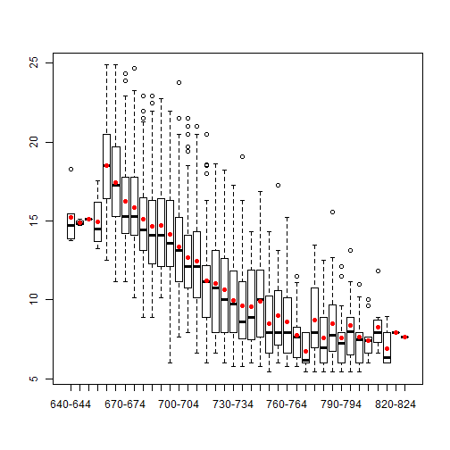

```r
# confint(lm1) anova(lm1)
plot(loansRaw$FICO.Range, rates)
points(loansRaw$FICO.Range, lm1$fitted, pch = 19, col = "red")
```

### Fit a rates by Length

```
lm2 <- lm(rates ~loansRaw$Loan.Length)
plot(loansRaw$Loan.Length, rates)
points(loansRaw$Loan.Length, lm2$fitted,pch=19,col="red")

#summary(lm2)
#confint(lm2)
#anova(lm2)
```

### Fit a rates by Amount.Requested

```
lm3 <- lm(rates ~loansRaw$Amount.Requested)
plot(loansRaw$Amount.Requested, rates)
points(loansRaw$Amount.Requested, lm3$fitted,pch=19,col="red")
#summary(lm3)
#confint(lm3)
#anova(lm3)
```

###Fit a rates by loansRaw$Amount.Funded.By.Investors

```
lm4 <- lm(rates ~ loansRaw$Amount.Funded.By.Investors)
plot(loansRaw$Amount.Funded.By.Investors, rates)
points(loansRaw$Amount.Funded.By.Investors, lm4$fitted,pch=19,col="red")
#summary(lm4)
#confint(lm4)
#anova(lm4)
```

###Fit a rates by loansRaw$Loan.Purpose

```
lm5 <- lm(rates ~ relevel(loansRaw$Loan.Purpose, ref="debt_consolidation"))
plot(loansRaw$Loan.Purpose, rates, las=2)
points(loansRaw$Loan.Purpose, lm5$fitted,pch=19,col="red")
#summary(lm5)
#confint(lm5)
#anova(lm5)
```

###Fit a rates by ratio

```
ratioGroups = cut(ratio,10)
lm6 <- lm(rates ~ ratioGroups)
plot(ratioGroups, rates, las=2)
points(ratioGroups, lm6$fitted,pch=19,col="red")
#summary(lm6)
#confint(lm6)
#anova(lm6)
```

```
lm7 <- lm(rates ~ loansRaw$State)
plot(loansRaw$State, rates, las=2)
points(loansRaw$State, lm7$fitted,pch=19,col="red")
#summary(lm7)
#confint(lm7)
#anova(lm7)
```

###Fit a rates by Ownership

```
lm8 <- lm(rates ~ loansRaw$Home.Ownership)
plot(loansRaw$Home.Ownership, rates, las=2)
points(loansRaw$Home.Ownership, lm8$fitted,pch=19,col="red")
#summary(lm8)
#confint(lm8)
#anova(lm8)
```

###Fit a rates by Monthly.Income

```
lm9 <- lm(rates ~ loansRaw$Monthly.Income)
plot(loansRaw$Monthly.Income, rates, las=2)
points(loansRaw$Monthly.Income, lm9$fitted,pch=19,col="red")
#summary(lm9)
#confint(lm9)
#anova(lm9)
```

###Fit a rates by Open.CREDIT.Lines

```
lm10 <- lm(rates ~ loansRaw$Open.CREDIT.Lines)
plot(loansRaw$Open.CREDIT.Lines, rates, las=2)
points(loansRaw$Open.CREDIT.Lines, lm10$fitted,pch=19,col="red")
#summary(lm10)
#confint(lm10)
#anova(lm10)
```

###Fit a rates by Inquiries.in.the.Last.6.Months

```
lm11 <- lm(rates ~ loansRaw$Inquiries.in.the.Last.6.Months)
plot(loansRaw$Inquiries.in.the.Last.6.Months, rates)
points(loansRaw$Inquiries.in.the.Last.6.Months, lm11$fitted,pch=19,col="red")
#summary(lm11)
#confint(lm11)
#anova(lm11)
```

###Fit a rates by loansRaw$Employment.Length

```
lm12 <- lm(rates ~ loansRaw$Employment.Length)
plot(loansRaw$loansRaw$Employment.Length, rates)
points(loansRaw$loansRaw$Employment.Length, lm12$fitted,pch=19,col="red")
#summary(lm12)
#confint(lm12)
#anova(lm12)
```